# Informal Sensitivity Analysis of Modeled Almond Prices in Response to Climate Variation

Author

Jaden Orli

Published

April 21, 2025

# I. Background

This document implements a profit model developed for the almond yield anomaly in response to climate variables.The transfer function for this model is sourced from Lobell et al. 2006 which used data to build statistical models of tree crop yield for California that explored how climate variation (place and time) might influence yield (Lobell, Cahill, and Field 2006). The particular equation used, shown below, is from Table 2 listed under almonds for the crop type.

$$Y = -0.015 \cdot T_{n2} - 0.0046 \cdot T_{n2}^2 - 0.07 \cdot P_{1} + 0.0043 \cdot P_{1}^2 + 0.28$$
The almond yield model calculates the annual almond yield anomaly for the input dates. The output of this model is then used in the almond profit model to adjust the baseline yield to an actual yield for each year. Additionally, this model will scale the actual yield the baseline price to calculate a final annual profit. An conceptual model is outlined later in the workflow to further visualize the process.

The objective of this model is to predict almond profit based on climate inputs (monthly minimum temperature and total monthly precipitation) and assumed parameters values (baseline annual yield and baseline annual price). Then we want to assess parameter uncertainty and identify key drivers of model dynamics. The values for baseline yield and baseline prices were interpreted from the UC Davis 2008 Sample Costs to Establish an Orchard and Produce Almonds (Stewart et al. 2008).

# II. Set Up

Now we can begin to set up the environment for analysis.

## a) Load Libraries

First, we will clear the environment and load the necessary libraries.

```r
#this clears out the environment
rm(list = ls())

#load the necessary libraries
library(readr)
library(here)
library(tidyverse)
library(kableExtra)
library(ggtext)
library(htmltools)
library(calecopal)
```

## b) Read Data

Then we will read in the climate data text file as a dataframe.

```r
#read in the climate data as a dataframe
climate_data <- read_delim(here("Data", "clim.txt"))
```

## c) Color Palettes

Finally, we can establish a color palette for this project.

```r
#create a color palette to use throughout the project
kelp1 <- cal_palette(name = "kelp1", n = 50, type = "continuous")

#create a named list of colors from the kelp1 palette
colors <- c(fill = "#0D5C66",
            median_profit = "#4E6934",
            mean_profit = "#D22600")

#create a color for baseline_price
baseline_price <- "coral"

#create a color for baseline_yield
baseline_yield <- "mediumorchid"
```

# III. Annual Almond Profit

After finishing to set up the work environment, we can begin to calculate the annual almond profit using our models.

## a) Conceptual Model

To help understand the almond_yield function and the almond_yield_profit function, we developed a conceptual model to explain the processes that take place within these function. The schematic for the almond yield function is outlined below:

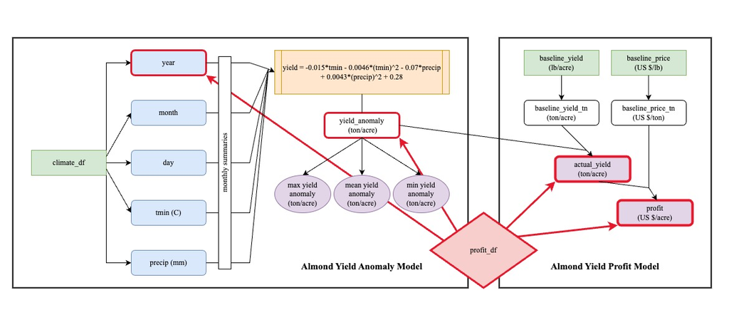

## b) Almond Yield Function

```r
#load in the almond_yield function
source(here("R", "almond_yield.R"))

#view the format of the function
almond_yield
```

```
function (climate_df, tmin_month, precip_month, return_summary = NULL)
{
    climate_month <- climate_df %>% group_by(month, year) %>%
        summarise(tmin_mean = mean(tmin_c), precip_sum = sum(precip),
            .groups = "drop")
    tmin_month_df <- climate_month %>% filter(month == tmin_month) %>%
        select(year, tmin_mean)
    precip_month_df <- climate_month %>% filter(month == precip_month) %>%
        select(year, precip_sum)
    climate_input <- inner_join(tmin_month_df, precip_month_df,
        by = "year")
    almond_yield_func <- function(tmin, precip) {
        yield <- -0.015 * tmin - 0.0046 * (tmin)^2 - 0.07 * precip +
            0.0043 * (precip)^2 + 0.28
        return(yield)
    }
    annual_yield <- climate_input %>% mutate(yield_anomaly = almond_yield_func(tmin_mean,
        precip_sum))
    if (!is.null(return_summary)) {
        yield_summary <- annual_yield %>% summarise(mean_yield = mean(yield_anomaly),
            max_yield = max(yield_anomaly), min_yield = min(yield_anomaly))
        return(yield_summary)
    }
    else {
        return(annual_yield)
    }
}
```

## c) Almond Yield Profit Function

Then we can load in the almond_yield_profit function to calculate the actual annual yield and the corresponding profit. This profit model assumes two parameter values, the baseline yield and the baseline price,

```r
#load in the almond_yield function
source(here("R", "almond_yield_profit.R"))

#view the format of the function
almond_yield_profit
```

```
function (climate_df, tmin_month, precip_month, baseline_yield,
    baseline_price)
{
    yield_df <- almond_yield(climate_df, tmin_month, precip_month) %>%
        select(year, yield_anomaly)
    baseline_yield_tn <- baseline_yield * 5e-04
    baseline_price_tn <- baseline_price/5e-04
    profit_df <- yield_df %>% mutate(actual_yield = baseline_yield_tn +
        yield_anomaly, profit = actual_yield * baseline_price_tn)
    return(profit_df)
}
```

# IV. Informal Sensitivity Analysis

After outlining the functions used in this workflow, we can run an informal sensitivity analysis to evaluate model reliability and determine which variables in the profit model drive the model dynamics.

## a) Set Up

First we will set up the model by creating a dataframe with various combinations of parameter values for the baseline price and baseline yield.

### i) Define Inputs

```r
#set the seed for reproducibility
set.seed(42)

#define the number of simulations to use
n_samples <- 100

#create a dataframe of sample parameter ranges for yield and price
sensitivity_inputs <- tibble(baseline_yield = runif(n_samples, #randomly sample from a uniform distribution n times
                                                    min = 1600, #minimum yield of 1600 lb/acre
                                                    max = 3200), #maximum yield of 3200 lb/acre
                             baseline_price = runif(n_samples, #randomly sample from a uniform distribution n times
                                                    min = 1.0, #minimum price of 1 $/lb
                                                    max = 2.3)) #maximum price of 2.3 $/lb
```

### ii) Profit Simulations

```r
#create a list of dataframes with the output of the various profit simulations using the sensitivity inputs from above
profit_simulations <- pmap(sensitivity_inputs, #use pmap to iterate over the tibble of parameters
                           function(baseline_yield, baseline_price) { #use the each row of the input tibble for a set of values for baseline_price and baseline_yield
  almond_yield_profit(climate_df = climate_data, #use the almond_yield_profit function with the climate data
                      tmin_month = 2, #use Feb for the min temp month like Lobell et al 2006
                      precip_month = 1, #use Jan for the precip month like Lobell et al 2006
                      baseline_yield = baseline_yield, #use the baseline_yield from this iteration of simulations
                      baseline_price = baseline_price) #use the baseline_price from this iteration of simulations
})

#create a dataframe with all the simulations from above
profit_dfs <- map2_dfr(profit_simulations, #input the list of 100 simulations
                       1:n_samples, #input a sequence of numbers from 1 to the number of simulations (n)
                       ~ mutate(.x, #create a new dataframe with each simulation dataframe
                                simulation = .y)) #add a column for the simulation number
```

## b) Parameter Uncertainity

To asses the reliability of the model under uncertainty, we visualized the variation in calculated profit across all simulations over time. In each of the below figures, the boxplot shows the variation in the calculated profit across all the simulations for each year. Additionally, the green line represents the annual median profit across all 100 simulations while the red line represents the annual mean profit across the simulations.

### i) Annual Profit Distributions

We started by visualizing the annual variation in profit distributions for all of the years.

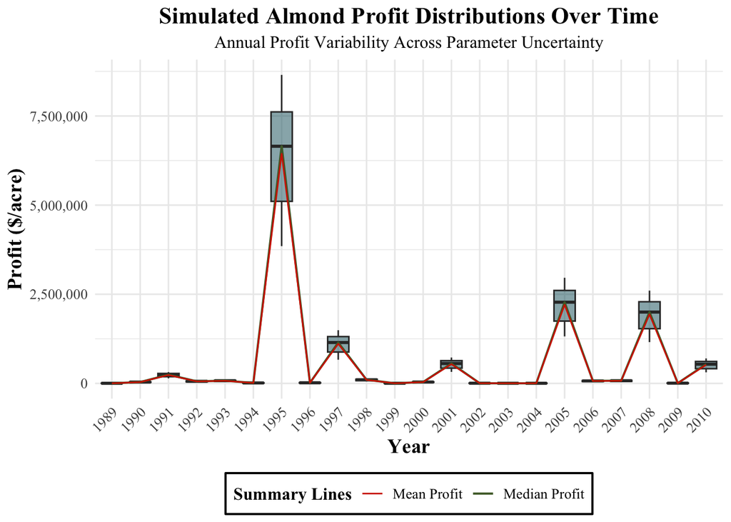

```r
#create a summary dataframe with the median profit and mean profit for each year across all simulations
profit_dfs_sum <- profit_dfs %>% #input the profits_df
  group_by(year) %>% #group the simulations by year
  summarize("median_profit" = median(profit), #calculate the median profit
            "mean_profit" = mean(profit)) #calculate the mean profit

#create a plot of the annual profit distributions for every year
profits_annual_sum <- ggplot(profit_dfs, aes(x = factor(year), y = profit)) + #plot profit for each year
  geom_boxplot(fill = colors["fill"], alpha = 0.5) + #use the fill color for the boxplots
  geom_line(data = profit_dfs_sum, #draw a green line for the median profit
            aes(x = factor(year), y = median_profit, color = "Median Profit", group = 1),
            size = 0.7) +
  geom_line(data = profit_dfs_sum, #draw a red line for the mean profit
            aes(x = factor(year), y = mean_profit, color = "Mean Profit", group = 1),
            size = 0.5) +
  scale_color_manual(name = "Summary Lines",
                     values = c("Median Profit" = colors[["median_profit"]],
                                "Mean Profit" = colors[["mean_profit"]])) +
  labs(title = "Simulated Almond Profit Distributions Over Time",
       subtitle = "Annual Profit Variability Across Parameter Uncertainty",
       x = "Year", y = "Profit ($/acre)") +
  scale_y_continuous(labels = scales::comma) +
  theme_minimal() +
  theme(text = element_text(family = "Times New Roman"),
        plot.title = element_text(face = "bold", size = 16, hjust = 0.5),
        plot.subtitle = element_text(size = 12, hjust = 0.5),
        axis.title = element_text(face = "bold", size = 14),
        axis.text = element_text(size = 10),
        axis.text.x = element_text(angle = 45, hjust = 1, vjust = 1),
        legend.position = "bottom",
        legend.box.background = element_rect(color = "black", size = 0.7),
        legend.title = element_text(face = "bold", size = 12),
        legend.text = element_text(size = 10))

#view the output
profits_annual_sum
```

However, due to the large variability in the calculated profit based on year, we facted the data into high, mid, and low profit levels for easier visualization.

```r
#create a dataframe with the ranked years based on the above boxplots
profit_facet <- profit_dfs %>% #input the profit_dfs
  mutate(rank = case_when(year %in% c(1995, 1997, 2001, 2005, 2008, 2010) ~ "high", #these are high profit years
                          year %in% c(1990, 1991, 1992, 1993, 1998, 2000, 2006, 2007) ~ "mid", #these are mid profit years
                          year %in% c(1989, 1994, 1996, 1999, 2002, 2003, 2004, 2009) ~ "low")) #these are low profit years

#create a summary dataframe for median and mean by year and rank
profit_facet_sum <- profit_facet %>% #input the profit_facet df
  group_by(rank, year) %>% #group the data by rank (high, mid, low) and year
  summarize(median_profit = median(profit), #calculate median profit
            mean_profit = mean(profit), #calculate mean profit
            .groups = "drop") #drop the groups
```

Now we can visualize the annual profit variation across the various profit levels:

### ii) High Profit Level

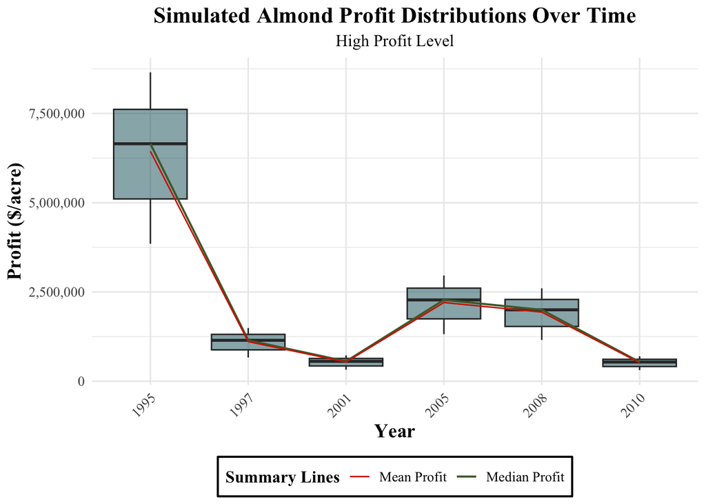

```r
#create a dataframe with the years with the highest profit
profit_high <- profit_facet %>% #input the profit_dfs
  filter(rank == "high") #select the years with high profit

#create a summary dataframe for the high profit dataframe
profit_high_sum <- profit_high %>% #input the profit_high
  group_by(year) %>% #group the simulations by year
  summarize(median_profit = median(profit), #calculate the median profit
            mean_profit = mean(profit)) #calculate the mean profit

#create a plot of the annual profit distributions for every year
profits_high_sum <- ggplot(profit_high, aes(x = factor(year), y = profit)) + #plot profit for each year
  geom_boxplot(fill = colors["fill"], alpha = 0.5) + #use the fill color for the boxplots
  geom_line(data = profit_high_sum, #draw a green line for the median profit
            aes(x = factor(year), y = median_profit, color = "Median Profit", group = 1),
            size = 0.7) +
  geom_line(data = profit_high_sum, #draw a red line for the mean profit
            aes(x = factor(year), y = mean_profit, color = "Mean Profit", group = 1),
            size = 0.5) +
  scale_color_manual(name = "Summary Lines",
                     values = c("Median Profit" = colors[["median_profit"]],
                                "Mean Profit" = colors[["mean_profit"]])) +
  labs(title = "Simulated Almond Profit Distributions Over Time",
       subtitle = "High Profit Level",
       x = "Year", y = "Profit ($/acre)") +
  scale_y_continuous(labels = scales::comma) +
  theme_minimal() +
  theme(text = element_text(family = "Times New Roman"),
        plot.title = element_text(face = "bold", size = 16, hjust = 0.5),
        plot.subtitle = element_text(size = 12, hjust = 0.5),
        axis.title = element_text(face = "bold", size = 14),
        axis.text = element_text(size = 10),
        axis.text.x = element_text(angle = 45, hjust = 1, vjust = 1),
        legend.position = "bottom",
        legend.box.background = element_rect(color = "black", size = 0.7),
        legend.title = element_text(face = "bold", size = 12),
        legend.text = element_text(size = 10))

#view the output
profits_high_sum
```

### iii) Mid Profit Level

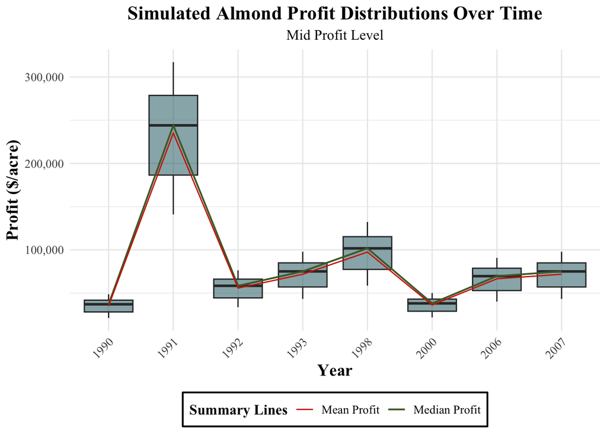

```r
#create a dataframe with the years with the mid profit
profit_mid <- profit_facet %>% #input the profit_dfs
  filter(rank == "mid") #select the years with mid profit

#create a summary dataframe for the profit_mid dataframe
profit_mid_sum <- profit_mid %>% #input the profit_mid
  group_by(year) %>% #group the simulations by year
  summarize(median_profit = median(profit), #calculate the median profit
            mean_profit = mean(profit)) #calculate the mean profit

#create a plot of the annual profit distributions for every year
profits_mid_sum <- ggplot(profit_mid, aes(x = factor(year), y = profit)) + #plot profit for each year
  geom_boxplot(fill = colors["fill"], alpha = 0.5) + #use the fill color for the boxplots
  geom_line(data = profit_mid_sum, #draw a green line for the median profit
            aes(x = factor(year), y = median_profit, color = "Median Profit", group = 1),
            size = 0.7) +
  geom_line(data = profit_mid_sum, #draw a red line for the mean profit
            aes(x = factor(year), y = mean_profit, color = "Mean Profit", group = 1),
            size = 0.5) +
  scale_color_manual(name = "Summary Lines",
                     values = c("Median Profit" = colors[["median_profit"]],
                                "Mean Profit" = colors[["mean_profit"]])) +
  labs(title = "Simulated Almond Profit Distributions Over Time",
       subtitle = "Mid Profit Level",
       x = "Year", y = "Profit ($/acre)") +
  scale_y_continuous(labels = scales::comma) +
  theme_minimal() +
  theme(text = element_text(family = "Times New Roman"),
        plot.title = element_text(face = "bold", size = 16, hjust = 0.5),
        plot.subtitle = element_text(size = 12, hjust = 0.5),
        axis.title = element_text(face = "bold", size = 14),
        axis.text = element_text(size = 10),
        axis.text.x = element_text(angle = 45, hjust = 1, vjust = 1),
        legend.position = "bottom",
        legend.box.background = element_rect(color = "black", size = 0.7),
        legend.title = element_text(face = "bold", size = 12),
        legend.text = element_text(size = 10))

#view the output
profits_mid_sum
```

### iv) Low Profit Level

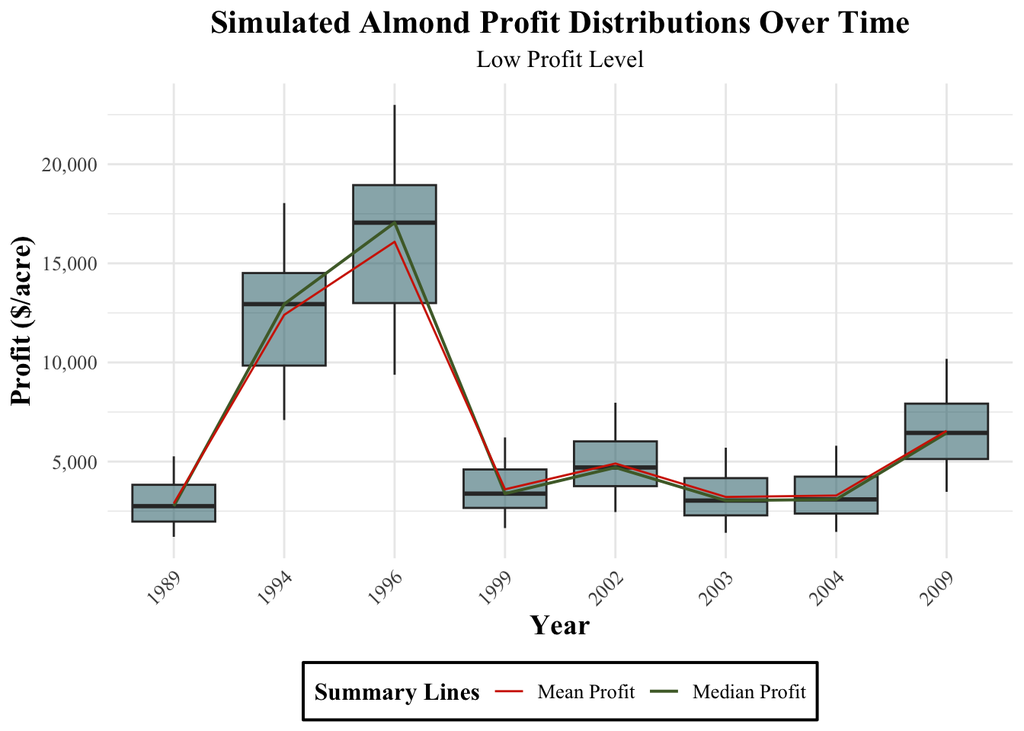

```r
#create a dataframe with the years with the lowest profit
profit_low <- profit_facet %>% #input the profit_dfs
  filter(rank == "low") #select the years with low profit

#create a summary dataframe for the profit_low dataframe
profit_low_sum <- profit_low %>% #input the profit_low
  group_by(year) %>% #group the simulations by year
  summarize(median_profit = median(profit), #calculate the median profit
            mean_profit = mean(profit)) #calculate the mean profit

#create a plot of the annual profit distributions for every year
ggplot(profit_low, aes(x = factor(year), y = profit)) +
  geom_boxplot(fill = colors["fill"], alpha = 0.5) + #use the fill color for the boxplots
  geom_line(data = profit_low_sum, #draw a green line for the median profit
            aes(x = factor(year), y = median_profit, color = "Median Profit", group = 1),
            size = 0.7) +
  geom_line(data = profit_low_sum, #draw a red line for the mean profit
            aes(x = factor(year), y = mean_profit, color = "Mean Profit", group = 1),
            size = 0.5) +
  scale_color_manual(name = "Summary Lines",
                     values = c("Median Profit" = colors[["median_profit"]],
                                "Mean Profit" = colors[["mean_profit"]])) +
  labs(title = "Simulated Almond Profit Distributions Over Time",
       subtitle = "Low Profit Level",
       x = "Year", y = "Profit ($/acre)") +
  scale_y_continuous(labels = scales::comma) +
  theme_minimal() +
  theme(text = element_text(family = "Times New Roman"),
        plot.title = element_text(face = "bold", size = 16, hjust = 0.5),
        plot.subtitle = element_text(size = 12, hjust = 0.5),
        axis.title = element_text(face = "bold", size = 14),
        axis.text = element_text(size = 10),
        axis.text.x = element_text(angle = 45, hjust = 1, vjust = 1),
        legend.position = "bottom",
        legend.box.background = element_rect(color = "black", size = 0.7),
        legend.title = element_text(face = "bold", size = 12),
        legend.text = element_text(size = 10))
```

## c) Key Drivers

Finally, we can explore the impact of the baseline price and baseline yield parameters on the model dynamics. In particular, we can evaluate if either of these parameters play a driving role in the model outcome.

```r
#create a summary dataframe with the parameter combinations and mean profit for each simulation
profit_summary <- profit_dfs %>% #input the profit_dfs
  group_by(simulation) %>% #group the data by simulation
  summarise(mean_profit = mean(profit)) %>% #calculate the mean_profit for each simulation
  left_join(sensitivity_inputs %>% #add on the sensitivity inputs dataframe
              mutate(simulation = row_number()), #first add a simulation column
            by = "simulation") #then join the two dataframes by this simulation column
```

### i) Sensitivity to Baseline Price

First, we will visualize the models sensitivity to the baseline price parameter by plotting the relationship between the baseline price and mean profit for each simulation.

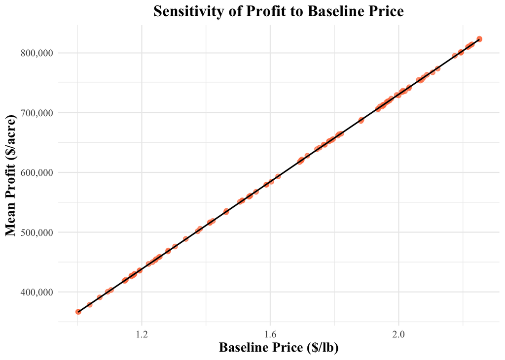

```r
#create a plot of the profit sensitivity to baseline price
profit_price <- ggplot(profit_summary, aes(x = baseline_price, y = mean_profit)) +
  geom_point(color = baseline_price, size = 2, alpha = 0.7) +
  geom_smooth(method = "loess", color = "black", se = FALSE, size = 0.7) +
  labs(title = "Sensitivity of Profit to Baseline Price",
       x = "Baseline Price ($/lb)",
       y = "Mean Profit ($/acre)") +
  scale_y_continuous(labels = scales::comma) +
  theme_minimal() +
  theme(text = element_text(family = "Times New Roman"),
        plot.title = element_text(face = "bold", size = 16, hjust = 0.5),
        axis.title = element_text(face = "bold", size = 14),
        axis.text = element_text(size = 10))

#view the output
profit_price
```

### ii) Sensitivity to Baseline Yield

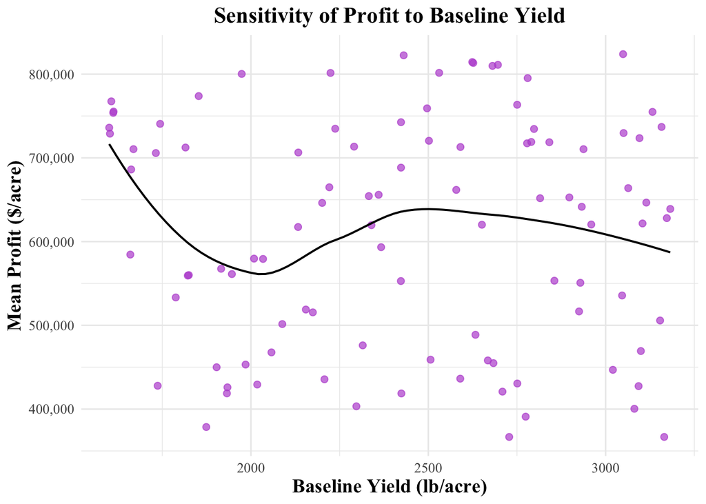

```r
#create a plot of the profit sensitivity to baseline price
profit_yield <- ggplot(profit_summary, aes(x = baseline_yield, y = mean_profit)) +
  geom_point(color = baseline_yield, size = 2, alpha = 0.7) +
  geom_smooth(method = "loess", color = "black", se = FALSE, size = 0.7) +
  labs(title = "Sensitivity of Profit to Baseline Yield",
       x = "Baseline Yield (lb/acre)",
       y = "Mean Profit ($/acre)") +
  scale_y_continuous(labels = scales::comma) +
  theme_minimal() +
  theme(text = element_text(family = "Times New Roman"),
        plot.title = element_text(face = "bold", size = 16, hjust = 0.5),
        axis.title = element_text(face = "bold", size = 14),
        axis.text = element_text(size = 10))

#view the output
profit_yield
```

### iii) Combined Visualization

Finally, we can examine a combined visualization in which the above plot of baseline yield is colored by the changes in baseline price.

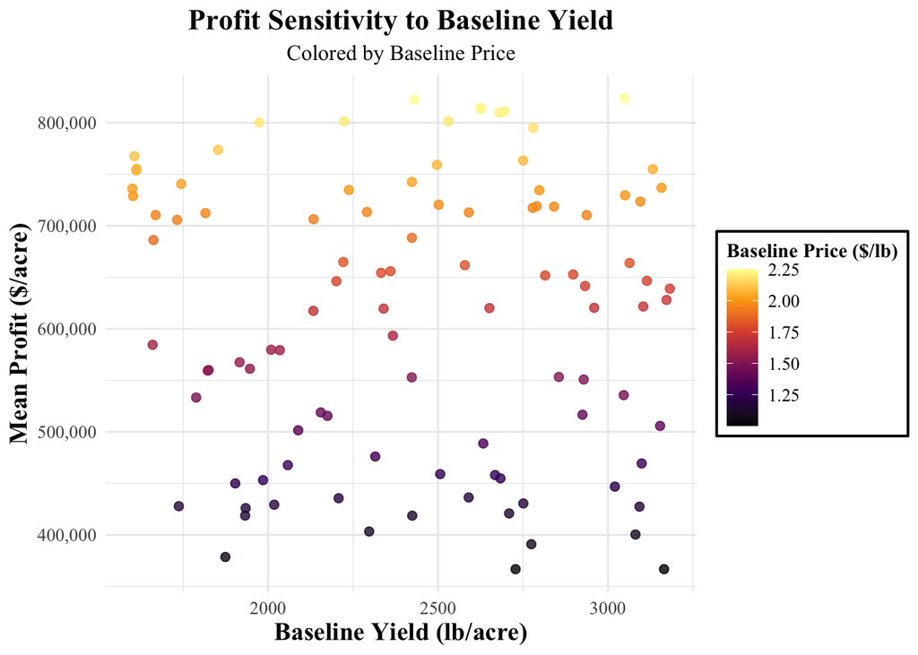

```r
#create a combined parameter visualization
profit_combined <- ggplot(profit_summary, aes(x = baseline_yield, y = mean_profit)) +
  geom_point(aes(color = baseline_price), size = 2, alpha = 0.8) +
  scale_color_viridis_c(option = "B", name = "Baseline Price ($/lb)") +
  labs(title = "Profit Sensitivity to Baseline Yield",
       subtitle = "Colored by Baseline Price",
       x = "Baseline Yield (lb/acre)",
       y = "Mean Profit ($/acre)") +
  scale_y_continuous(labels = scales::comma) +
  theme_minimal() +
  theme(text = element_text(family = "Times New Roman"),
        plot.title = element_text(face = "bold", size = 16, hjust = 0.5),
        plot.subtitle = element_text(size = 12, hjust = 0.5),
        axis.title = element_text(face = "bold", size = 14),
        axis.text = element_text(size = 10),
        legend.title = element_text(face = "bold", size = 11),
        legend.box.background = element_rect(color = "black", size = 0.7),
        legend.text = element_text(size = 10))

#view the output
profit_combined
```

# V. Discussion

Based on the sensitivity analysis we can conclude that our model is a reliable predictor of almond profit and that the baseline price is the driving parameter. From our parameter uncertainty analysis, we see that the data are fairly normally distributed with the median almost equal to the mean in most years across high, mid, and low profit returns. This means that there is less variability and risk associated with using this model to predict profit based on yield and climate variations making this a reliable model. Additionally, our key drivers analysis revealed that baseline price dominated the model dynamics while baseline yield was not a strong predictor of profit. This is apparent in the strong linear relationship between baseline price and mean profit and the noisy relationship between baseline yield and mean profit. The combined visualization highlights these relationships nicely together in a single plot.

# VI. References

Lobell, David B., Kelly N. Cahill, and Christopher B. Field. 2006. “Climate Variability and Crop Production in California.” https://doi.org/10.1016/j.agee.2005.11.001.

Stewart, David, Rodney Duncan, Bobby Aegerter, William Coates, Karen Klonsky, and Roy De Moura. 2008. “Sample Costs to Establish an Orchard and Produce Almonds in the Sacramento Valley – North.” Davis, California: University of California Cooperative Extension. https://coststudies.ucdavis.edu/en/current/commodity/almonds/.